# Table of Contents

```python
%%javascript # for table of content
$.getScript('https://kmahelona.github.io/ipython_notebook_goodies/ipython_notebook_toc.js')
```

# PROJECT EUCLID

This is a project on euclidean distances for large mtrices as a metric for clustering set of points in a n-dimensional space. It is done in R and python with extention in C and C++ to explore possible speed gains.

## R

### Ungrouped

In R, we compare times with the base R function utils::dist . Here are the five functions used

1. dist: This is the base R function. However it is technically a C function except that the output is formatted for readability.
2. eucdist_R: This function uses vectorization in R to calculate distance between any two n-dimensional vectors
3. dotprod: This function uses dot product to calculate distance between any two n-dimensional vectors. It uses pure R
4. eucdist_C: This function uses a C wrapper in R to calculate distances for a given matrix
5. fastdist2: This uses a C++ function loaded into R using Rcpp package

Note that 2 and 3 takes vectors as input. They can be called on every combinations of rows in an n-dimensianal matrix using the euc_func function below. The ouputs can be formatted as a "dist" object using the function mefa::vec2dist for easy viewing. To calculate the distances for a matrix, euc_func takes two arguments: the matrix and the function to be used.

```python
%load_ext rpy2.ipython
```

```python
import warnings
warnings.filterwarnings('ignore')
```

```python
%%R

# This function uses one of the above method to calculate distance between rows
euc_func <- function(dist_func, M){
  # takes a distance calculating function as a string (for two points)
  # function dist_func and a matrix M
  # returns the distance between rows of matrix M
  f <- match.fun(dist_func) # as a function
  n <- nrow(M)
  l <- n*(n-1)/2
  last_element <- f(M[n,], M[n-1, ])
  distance <- numeric(l)
  distance[l] <- last_element
  k <- 1 # for indexing the distance vector
  for(i in 1:(n-1)){

    A = M[i, ]
    # removing the column containing A
    for(j in (i + 1):n){
      #print(j)
      B <- M[j, ]
      distance[k] <- f(A, B)
      k <- k + 1

    }

  }
#   return( mefa::vec2dist(distance, n)  ) # vect2dist formats the output
    return( distance )

}
```

The code for the dot product method(3) and vectorization method.

## Dot Product

```python
%%R
# (1) Dot Product
dot_prod_dist <- function(A, B){
  # function for computing euclidean distances using dot-product
  # Arguements : A and B are vectors of the same length
  # Outputs: The Euclidean distance between A and B


  # checking if the vectors are in the same dimension.
  # for the most part it is a wastefull check
  #if(length(A) != length(B)) stop('Invalid input(s)')

  u <- A - B
  return(sqrt(sum(u*u)))
}
```

## Vectorization

```python
%%R
#(2) using vectorization in R
e_dist <- function(A, B){
  # calculating the distance between vectors A and B
  #if(length(A) != length(B)) stop('Invalid Input(s)')

  return( sqrt(sum((A - B)^2)) )

}
```

The C and C++ function uses the same loop with the calculation done using a loop

## The C Function

The C function is in a file called eucdist.c. After compiling, the .so is loaded using dyn.load and then used in an R wrapper below

```python
%%bash
cat C_C++/eucdist.c
```

```
#include <math.h>
#include <R.h>
#include <Rinternals.h>
#include <stdio.h>
/* Euclidean distance */
/*q=.C("eucdist",as.integer(c(1,2,3,4,5,6,7,8)),as.integer(4),as.integer(2),as.double(vector("double",6))*/
void eucdist(double *x, int *m, int *n, double *d)
{
  /* Arguement:
    1.  x is a matrix of dimension n by m
    2.  m is the number of rows
    3.  n is the number of coloums
    4.  d is the pointer for output */
  /*
   d = sqrt(sum((XI-XJ).^2,2));            % Euclidean
   */
  int i,j,k; /* **pointer; /* Indexers */
  int local_m, local_n;
  local_m = *m, local_n = *n;
  double theSum; /* size_t is an unsigned integer of size 16 bits */
  /*
  XI for indexing rows
  XJ for indexing columns
  XI0 unknown for now
  */
  int  XI, XJ, XI0, index; /* pointers as row indexers*/
  // d = malloc( local_m*(local_m - 1)/2);
  // XI0 =  (double *) x; /* we are not tuching x but using its memory address as XI */
  // x = (double) x;
  index = 0;

  for (i=0; i<local_m-1; ++i) {
    XI = i*local_n; //indexing the start of the i the row
    XI0 = XI;
    // Rprintf("XI is %d\n", XI);
    for (j=i+1; j<local_m; ++j) {
      XJ = j*local_n; // indexing the start of the start jth row
      // Rprintf("XJ is %d\n", XJ);
      // XI = XI0; /* Index? */
      theSum = 0.0;
      for (k=0;k<local_n;k++,++XI,++XJ){
        theSum += pow((x[XI]- x[XJ]), 2.0);
      }
      XI = XI0;
      d[index++] = sqrt(theSum);
    }
  }
}
```

```python
%%R
eucdist_C <- function(M){
    nr = as.integer(nrow(M))
    if(nr <= 1) {
        warning("Euclidean distances for a sinle point?")
        return(NULL)
        }
    # M is a matrix
    out <- .C("eucdist",
        x = as.vector(t(M), "double"),
        m = nrows,
        n = as.integer(ncol(M)),
        d = as.double(vector("double", nr*(nr)-1)/2)
    )
    #return(vec2dist(as.vector(out$d), nrows))
    return(out$d)
}
```

## The C++ Function

```python
%%bash
cd /home/medfad/Desktop/WD/2019/Abdul/Project_Euclid
cat C_C++/fastdist2.cpp
```

```
#include <Rcpp.h>
using namespace Rcpp;

// [[Rcpp::export]]
NumericVector fastdist2 (const NumericMatrix & x){
  unsigned int outrows = x.nrow(), i = 0, j = 0,k=-1;
  Rcpp::NumericVector out(outrows*(outrows-1)/2); /* empty matrix */

  for (i = 0; i <= outrows-2; i++){
    for (j = i + 1; j <= outrows-1 ; j ++){
      k++;
      out(k) = sqrt(sum(pow(x.row(i)-x.row(j), 2.0)));
    }
  }
  // out(outrows*(outrows-1)/2) = sqrt(sum(pow(x.row(outrows)-x.row(outrows-1), 2.0)));
  return out;
}
```

The function is sourced using Rcpp::sourceCpp

```python
%%R
Rcpp::sourceCpp("C_C++/fastdist2.cpp")
```

# Testing for Consistency

A matrix of 1000 rows is used to check that the functions produced the same output with a seed of 1 for consistency. All of the function used are declared/sourced from in the R script functions.R

```python
%%R
set.seed(1)
M <- matrix(rnorm(2000, 10, 10), ncol = 2)
head(M)
```

```
          [,1]      [,2]
[1,]  3.735462 21.349651
[2,] 11.836433 21.119318
[3,]  1.643714  1.292224
[4,] 25.952808 12.107316
[5,] 13.295078 10.693956
[6,]  1.795316 -6.626489
```

```python
%%bash
R CMD SHLIB C_C++/eucdist.c
```

```
make: Nothing to be done for 'all'.
```

```python
%%R
dyn.load("C_C++/eucdist.so")
```

```python
%%R
source("/home/medfad/Desktop/WD/2019/Abdul/Project_Euclid/R_code/functions.R")
```

```python
%%R
d1 <- dotprod(M)
d2 <- eucdist_C(M)
d3 <- eucdist_R(M)
d4 <- as.vector(dist(M)) # this output is format as an upper triangular matrix. so it is coverted to a vector
d5 <- fastdist2(M)
```

```python
%%R
#compairing the first ten elements of each output
# however this is done for smaller inputs and they give exactly the same output
cat("d1[1:10]: ", d1[1:10], "\n\n", "d2[1:10]: " ,
    d2[1:10], "\n\n", "d3[1:10]: ", d3[1:10], "\n\n", "d4[1:10]: ", d4[1:10], "\n\n", "d5[1:10]: ", d5[1:10], "\n\n")
```

```
d1[1:10]:  8.104245 20.1662 24.06307 14.31538 28.04333 11.60083 33.38971 26.67949 3.489988 27.16704

 d2[1:10]:  8.104245 20.1662 24.06307 14.31538 28.04333 11.60083 33.38971 26.67949 3.489988 27.16704

 d3[1:10]:  8.104245 20.1662 24.06307 14.31538 28.04333 11.60083 33.38971 26.67949 3.489988 27.16704

 d4[1:10]:  8.104245 20.1662 24.06307 14.31538 28.04333 11.60083 33.38971 26.67949 3.489988 27.16704

 d5[1:10]:  8.104245 20.1662 24.06307 14.31538 28.04333 11.60083 33.38971 26.67949 3.489988 27.16704
```

# Timing The Functions

The timing package rbenchmarks is used. It calculates the average time for a number of replication of the same function. Here, we used 25 replications for small inputs and 10 above 1000 rows. The output for each function's timing is a dataframe with two columns: test(name of the function) and the time elapsed. A columns for relative timings is also added. The relative column is calculated with respect to the base function "dist". Since the smaller the time the better, we divided each function's time by base R function's time. Example if base R took 0.04 seconds and one of the functions took 0.01 seconds, then that function is 0.04/0.01 (= 4 ) times faster than base R. The code for timing is in euclid_timer.R . It should be noted that this timings are done on linux(ubuntu 19.04 Disco Dingo) on 4 GB. So it might be different for PCs/Operatiing systems with different specifications but the relative times should be nearly the same.

```python
%%R
```

```python
%%bash
cat R_code/euclid_timer.R
```

```
 source("R_code/functions.R")


set.seed(1)
require('rbenchmark')
sink("small_inputs.txt", append = TRUE)
# the test is done with a 2 coloumn matrix( vectors in 2 dim  ensions )
nrows = c(5, 10, 25, 50, 75, 100, 200, 250, 500)
# nrows = c(10000)

funcs <- c("dist", "dotprod", "eucdist_C", "eucdist_R", "fastdist2")
l <- length(funcs)
Srelative_times <- data.frame(row.names = funcs)
col_index = 1 # for indexing the columns of the relative time dataframe
cat("This records the average times for 25 executions of each function\n")
for(i in nrows){
    cat(i, "by", 2, "\n")
    M <- matrix(rnorm(i*2, 10, 10), ncol = 2)
    #print(M)
    timer <- benchmark(
                dotprod(M),
                eucdist_R(M),
                dist(M),
                fastdist2(M),
                eucdist_C(M),
                columns = c("test", "elapsed"),
                replications = 25
        )

    t_base = timer$elapsed[1] # time for dist(M), the base R function

    Srelative_now <- numeric(l) # vector to contain the relative time for each iteration
    for(rows in 1:l){
        relative_now[rows] <- round(t_base/timer$elapsed[rows], 4)
    }
    Srelative_times[col_index] <- relative_now
    col_index <- col_index + 1
    timer$relative <- relative_now
    print(timer)
    cat("\n", paste(rep("*", 100), collapse = ""), "\n")
```

[output cut: 35 more lines]

```
    t_base = timer$elapsed[1] # time for dist(M), the base R function

    relative_now <- numeric(l) # vector to contain the relative time for each iteration
    for(rows in 1:l){
        relative_now[rows] <- round(t_base/timer$elapsed[rows], 4)
    }
    Lrelative_times[col_index] <- relative_now
    col_index <- col_index + 1
    timer$relative <- relative_now
    print(timer)
    cat("\n", paste(rep("*", 100), collapse = ""), "\n")
}
names(Lrelative_times) <- nrows
saveRDS(Lrelative_times, file = "Lrelative_times.rds")
sink()
```

## Times for Small Inputs

```python
%%bash
cat small_inputs.txt
```

```
This records the average times for 25 executions of each function
5 by 2
          test elapsed relative
3      dist(M)   0.001   1.0000
1   dotprod(M)   0.003   0.3333
5 eucdist_C(M)   0.001   1.0000
2 eucdist_R(M)   0.002   0.5000
4 fastdist2(M)   0.001   1.0000

10 by 2
          test elapsed relative
3      dist(M)   0.001   1.0000
1   dotprod(M)   0.007   0.1429
5 eucdist_C(M)   0.002   0.5000
2 eucdist_R(M)   0.006   0.1667
```

[output cut: 73 more lines]

## Times for Large Inputs

```python
%%bash
cat large_inputs.txt
```

```
This records the average times for 10 executions of each function
2500 by 2
          test elapsed relative
3      dist(M)   0.776   1.0000
1   dotprod(M) 111.565   0.0070
5 eucdist_C(M)   0.246   3.1545
2 eucdist_R(M) 102.172   0.0076
4 fastdist2(M)   3.910   0.1985

3000 by 2
          test elapsed relative
3      dist(M)   1.348   1.0000
1   dotprod(M) 155.299   0.0087
5 eucdist_C(M)   0.334   4.0359
2 eucdist_R(M) 147.574   0.0091
```

[output cut: 17 more lines]

The relative times are merged in a dataframe and save in an Rdata file relative_times.rds, and the plotting is done in ggplot2.

```python
require(ggplot2)
relative_times <- as.data.frame(t(readRDS("relative_times.rds")))
time_base = readRDS("time_base.rds") # the base R times)
n = as.numeric(row.names(relative_times))

g = ggplot(data = relative_times, aes(x = n))
g1 = g + geom_line(aes(y = dotprod, color = "dotprod", size=2.5))+ geom_line(aes(y = eucdist_C, color = "eucdist_C"))
g2 = g1 + geom_line(aes(y = dist, color = "dist")) + geom_line(aes(y = eucdist_R, color = "eucdist_R", size = 2))
g3 <- g2 + geom_line(aes(y = fastdist2, color = "fastdist2"))
g4 <- g3 + scale_color_manual(NULL,
            values=c(dotprod = "green", eucdist_R = "cyan", dist= "black",
            fastdist2 = "darkblue", eucdist_C = "red")) +
            theme(legend.text = element_text(size=18)) + labs(y ="Relative Times", x = "Number of rows")
```

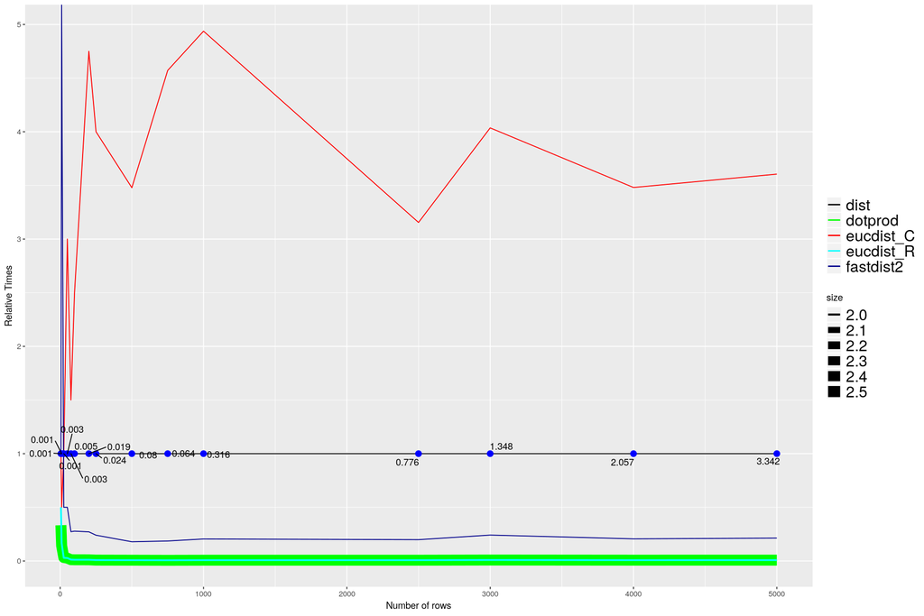

```python
# %%R
library(repr); library(ggrepel)

options(repr.plot.width=15, repr.plot.height = 10)
g4 + annotate("point", x = n, y = 1, color = "blue", size=3) + geom_text_repel(aes(x = sort(n), y = 1, label = time_base))
```

### Note that the lines for eucdist_R and dotprod are superimposed on each other. Here is a closer look at their comparison

```python
# %%R
g5 = g + geom_line(aes(y = dotprod, color = "dotprod")) +
    geom_line(aes(y = eucdist_R, color = "eucdist_R")) +  scale_color_manual(NULL,
    values=c(dotprod = "green", eucdist_R = "cyan")) +
    theme(legend.text = element_text(size=14)) + ylim(0.005, 0.035) + labs(y ="Relative Times", x = "Number of rows")
```

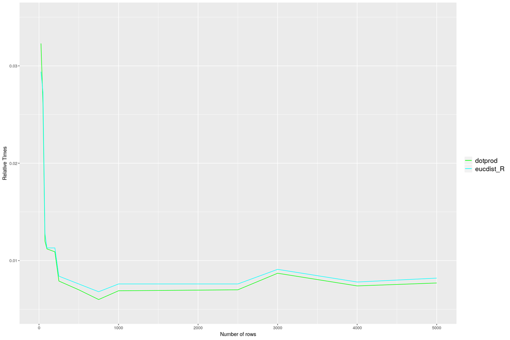

```python
g5
```

```python
# %%R
relative_times <- as.data.frame(t(readRDS("relative_times.rds")))
relative_times
```

A data.frame: 15 × 5

|  | dist <dbl> | dotprod <dbl> | eucdist_C <dbl> | eucdist_R <dbl> | fastdist2 <dbl> |
| --- | --- | --- | --- | --- | --- |
| 5 | 1 | 0.3333 | 1.0000 | 0.5000 | 1.0000 |
| 10 | 1 | 0.1429 | 0.5000 | 0.1667 | Inf |
| 25 | 1 | 0.0323 | 1.0000 | 0.0294 | 0.5000 |
| 50 | 1 | 0.0261 | 3.0000 | 0.0273 | 0.5000 |
| 75 | 1 | 0.0120 | 1.5000 | 0.0128 | 0.2727 |
| 100 | 1 | 0.0112 | 2.5000 | 0.0113 | 0.2778 |
| 200 | 1 | 0.0109 | 4.7500 | 0.0113 | 0.2714 |
| 250 | 1 | 0.0079 | 4.0000 | 0.0084 | 0.2400 |
| 500 | 1 | 0.0070 | 3.4783 | 0.0076 | 0.1790 |
| 1000 | 1 | 0.0069 | 4.9375 | 0.0076 | 0.2051 |
| 2500 | 1 | 0.0070 | 3.1545 | 0.0076 | 0.1985 |
| 3000 | 1 | 0.0087 | 4.0359 | 0.0091 | 0.2413 |
| 5000 | 1 | 0.0077 | 3.6052 | 0.0082 | 0.2132 |
| 4000 | 1 | 0.0074 | 3.4805 | 0.0078 | 0.2062 |
| 750 | 1 | 0.0060 | 4.5714 | 0.0068 | 0.1860 |

## Conclusion

```python
%%bash
cat out_compareAf.txt
```

```
This records the average times for 50 executions of each function
5 by 2
            test elapsed relative
3        dist(M)   0.001   1.0000
1     dotprod(M)   0.005   0.2000
5   eucdist_C(M)   0.015   0.0667
2   eucdist_R(M)   0.005   0.2000
4 fastdist2_R(M)   0.007   0.1429

10 by 2
            test elapsed relative
3        dist(M)   0.001   1.0000
1     dotprod(M)   0.006   0.1667
5   eucdist_C(M)   0.002   0.5000
2   eucdist_R(M)   0.006   0.1667
```

[output cut: 75 more lines]

```python
dist # the .Call bit is using R's C API to call a C function
```

```
function (x, method = "euclidean", diag = FALSE, upper = FALSE,
    p = 2)
{
    if (!is.na(pmatch(method, "euclidian")))
        method <- "euclidean"
    METHODS <- c("euclidean", "maximum", "manhattan", "canberra",
        "binary", "minkowski")
    method <- pmatch(method, METHODS)
    if (is.na(method))
        stop("invalid distance method")
    if (method == -1)
        stop("ambiguous distance method")
    x <- as.matrix(x)
    N <- nrow(x)
    attrs <- if (method == 6L)
        list(Size = N, Labels = dimnames(x)[[1L]], Diag = diag,
            Upper = upper, method = METHODS[method], p = p, call = match.call(),
            class = "dist")
    else list(Size = N, Labels = dimnames(x)[[1L]], Diag = diag,
        Upper = upper, method = METHODS[method], call = match.call(),
        class = "dist")
    .Call(C_Cdist, x, method, attrs, p)
}
```

# Grouped

In R, the following functions were written for grouped distance calculation. Each of the function takes three input: M (the matrix), group_vec(grouping vector) and format_output (a logical, if TRUE coverts the output in eah group into a dist object)

1. eucdist: This funtion is written to accept a function FUN that can calculate distances for any given matrix. it does this for all groupes and return the output as a list indexed by the names of the groups. it can used to called the funtions eucdist_C, eucdist_R, dist, fastdist2 on a grouped matrix.
2. eucdist_DT: This uses data.table to call a function for calculating distances on a matrix on all groups. The ouput is a data.table. For efficincy, the eucdist_C is used since it is the fastest for ungrouped.
3. eucdist_group_C: This is the function where the looping over groups is done in C.

### eucdist

```python
%%R
eucdist <- function(M, group_vec=NULL, format_output=FALSE, FUN = "eucdist_C"){
    f = match.fun(FUN)
    ifelse(is.null(group_vec), ifelse(format_output, return(mefa::vec2dist(f(M), nrow(M))), return(f(M))), "")

    unique_groups <- sort(unique(group_vec)) # all unique groups
    for_one_group <- function(group_used){
        row_index <- group_vec==group_used
        if(sum(row_index) <=1) return(NULL)
        # if(length(row_index)==1) return()
        output = f(M[row_index, ])
        if(format_output) return(mefa::vec2dist(output, sum(row_index)))

        return(output)
    }
    names(unique_groups) <- unique_groups
    sapply(unique_groups, for_one_group, simplify = "array")


}
```

### eucdist_DT

```python
%%R
require(data.table)
eucdist_DT <- function(M, group_vec, func="eucdist_C"){
    f = match.fun(func)
    M <- data.table(M, group_vec)
    output <- M[, f(.SD), by=group_vec][order(group_vec)]
    return(output)

}
```

```
R[write to console]: Loading required package: data.table
```

### eucdist_group_C

```python
%%bash
cat Group/eucdist_group.c
```

```
#include <math.h>
#include <R.h>
#include <Rinternals.h>
#include <stdio.h>
#include <stdlib.h>
// #include <string.h>

void eucdist_group(double *x, int *m, int *n, double *d, int *unique_group, int *l, int *group_vec, int *lg)
{
  /* Arguement:
    1.  x is a matrix of dimension n by m
    2.  m is the number of rows
    3.  n is the number of coloums
    4.  d is the pointer for output
    5.  unique_group is the pointer for the unique groups
    6.  l is the number of elements in the unique groups
    7.  group_vec is the grouping vector(
      it's length must be the same as the number of rows of x)
    */

  /*
  counter: for picking out the indices of a group
  indexer1: for filling the vector containing the indicies of where a particular group occurs
  indexer2: for indexing the output vector d
   */


  int local_m = *m, local_n = *n, counter = 0, unique_length = *l,
  indexer1, indexer2 = 0, g, h, i, j, k, XI, XJ, XI0, group_length;
  double theSum;

  for(i=0; i < unique_length; i++){
    group_length = lg[i];
    int group_index[group_length];
    counter = 0;
    indexer1 = -1;
    for(j=0; j<local_m; j++, counter++){

      if( unique_group[i] == group_vec[j] ){
        indexer1 += 1;
```

[output cut: 8 more lines]

```
        for(h=g+1; h < group_length; h++){
          XJ = local_n* group_index[h];

          theSum = 0.0;
          for (k=0;k<local_n;k++,++XI,++XJ){
            theSum += pow((x[XI]- x[XJ]), 2.0);
          }
          XI = XI0;
          d[indexer2++] = sqrt(theSum);

        }
      }

    }
}
```

```python
%%bash
R CMD SHLIB Group/eucdist_group.c
```

```
make: Nothing to be done for 'all'.
```

```python
%%R
# Using C with looping in C
# system("R CMD SHLIB Group/eucdist_group.c")

# loading it into R
dyn.load("Group/eucdist_group.so")

eucdist_group_C <- function(M, group_vec, format_output = FALSE) {
    unique_group = sort(unique(group_vec))
    tt = as.integer(table(group_vec))
    tot_length = vapply(tt, function(n) n*(n-1)/2, 0)
    l = length(unique_group)
    ifelse(is.integer(group_vec), group_vec_int <- group_vec, group_vec_int <- as.numeric(as.factor(group_vec)))
    nn <- 1:l
    out <-.C("eucdist_group",
        x = as.vector(t(M), "double"),
        m = as.integer(nrow(M)),
        n = as.integer(ncol(M)),
        d = vector("double", sum(tot_length)),
        unique_group = as.integer(nn),
        l = as.integer(l),
        group_vec = as.integer(group_vec_int),
        lg = tt
    )
    output = split( out$d, rep(unique_group, tot_length) )
    Nm <- names(output)
    if(format_output){
         # This function fornat the outputs as a dist object
         f = function(i){
                j <- which(Nm == i)
                k <- which(unique_group == i)
                mefa::vec2dist(output[[j]], tt[k])
            }
        return(sapply(Nm, f, simplify = "array"))

    }
    return(output)
}
```

# Testing for Consistency (Grouped)

```python
%%R
source("R_code/functions.R")
set.seed(1)

m = 20; n = 3; g = 3;
# m : number of rows
# n : number of colums
# g : number of distint groups

group_vec <- sample(c("one", "two", "three"), 10, TRUE)
M <- matrix(rnorm(m*n, 10, 10), ncol = n)
data.frame(M, group_vec)
```

```
           X1        X2         X3 group_vec
1    1.795316  9.438713  2.9250484       one
2   14.874291  8.442045 13.6458196       two
3   17.383247 -4.707524 17.6853292       two
4   15.757814  5.218499  8.8765379     three
5    6.946116 14.179416 18.8110773       one
6   25.117812 23.586796 13.9810588     three
7   13.898432  8.972123  3.8797361     three
8    3.787594 13.876716 13.4111969       two
9  -12.146999  9.461950 -1.2936310       two
10  21.249309 -3.770596 24.3302370       one
11   9.550664  5.850054 29.8039990       one
12   9.838097  6.057100  6.3277852       two
13  19.438362  9.406866 -0.4413463       two
14  18.212212 21.000254 15.6971963     three
15  15.939013 17.631757  8.6494540       one
16  19.189774  8.354764 34.0161776     three
17  17.821363  7.466383  9.6076000     three
18  10.745650 16.969634 16.8973936       two
19  -9.893517 15.566632 10.2800216       two
20  16.198257  3.112443  2.5672679       one
```

```python
%%R
funcs <- c("dist", "dotprod", "eucdist_C", "eucdist_R", "fastdist2")
for(FUN in funcs){
    cat("Using FUN = ", FUN, "\n")
    print(eucdist(M, group_vec, FUN = FUN, format_output = TRUE))
    cat("\n\n")
}

cat("\n\nUsing data.table\n")
eucdist_DT(M, group_vec)
```

```
Using FUN =  dist
$one
         1        2
2 17.36004
3 31.79820 28.20464

$three
          1         2
2 21.238173
3  6.520354 17.366900

$two
          1         2         3
2 13.982977
3 12.349313  9.198088
4 30.893000 14.839470 10.016895



Using FUN =  dotprod
$one
         1        2
2 17.36004
3 31.79820 28.20464

$three
          1         2
2 21.238173
3  6.520354 17.366900

$two
          1         2         3
2 13.982977
3 12.349313  9.198088
4 30.893000 14.839470 10.016895



Using FUN =  eucdist_C
$one
```

[output cut: 103 more lines]

```
45:       two 12.162635
46:       two 21.373326
47:       two  8.374619
48:       two 14.136226
49:       two 23.516450
50:       two 31.596906
51:       two 30.188608
52:       two 13.277604
53:       two 12.215038
54:       two 15.219187
55:       two 22.257313
56:       two 20.818036
57:       two 31.831581
58:       two 21.719421
    group_vec        V1
```

```python
%%R
cat("With the looping in C\n")
(eucdist_group_C(M, group_vec, format_output = TRUE))
```

```
With the looping in C
$one
         1        2
2 17.36004
3 31.79820 23.60604

$three
          1         2
2 21.238173
3  6.520354 21.011898

$two
         1        2        3
2 13.98298
3 12.34931 23.41973
4 30.89300 37.85512 22.12766
```

Note that all the functions allow both numeric and characters input as the grouping vector

# Timings

The timing are done with a n by 2 matrix where n is the number of rows. The group number is kept at 50 since this will allow the function to work on groups of bigger size as the n increases.

```python
%%R
# Note that the result for this has already been export to txt and rds file for reproducibility so
# THIS WON'T RUN
if(FALSE){
set.seed(1)
require('rbenchmark')
if(file.exists("group_times.txt")) system("rm group_times.txt")
sink("group_times.txt", append = TRUE)

nrows = sort(c(500, 1000, 2000, 3000, 5000, 7000, 10000, 15000, 20000, 25000, 30000, 40000))

# nrows = sort(c(40000, 50000))


funcs <- c("dist", "dotprod", "eucdist_C", "eucdist_R", "fastdist2", "eucdist_DT", "eucdist_c_loop")
time_base <- numeric(length(funcs)); j = 1
# l <- length(funcs)
Grelative_times <- data.frame(row.names = sort(funcs))
col_index = 1 # for indexing the columns of the relative time dataframe
cat("This records the average times for 25 executions of each function\n")
for(i in nrows){
    cat(i, "by", 2, "\n")
    M <- matrix(rnorm(i*2, 2, 10), ncol = 2)
    group_vec <- sample(1:50, i, T)
    #print(M)
    timer <- benchmark(
                dotprod = eucdist(M, group_vec, FUN = "dotprod"),
                eucdist_R = eucdist(M, group_vec, FUN = "eucdist_R"),
                dist = eucdist(M, group_vec, FUN = "dist"),
                fastdist2 = eucdist(M, group_vec, FUN = "fastdist2"),
                eucdist_C = eucdist(M, group_vec, FUN = "eucdist_C"),
                eucdist_c_loop = eucdist_group_C(M, group_vec),
                eucdist_DT = eucdist_DT(M, group_vec),
                columns = c("test", "elapsed"),
                replications = 25
        )

    t_base = timer$elapsed[1] # time for dist(M), the base R function
    time_base[j] = t_base; j <- j + 1
    relative_now <- round(t_base/timer$elapsed, 4)
    Grelative_times[col_index] <- relative_now
    col_index <- col_index + 1
    timer$relative <- relative_now
    # row.names(timer) <- funcs
    print(timer)
    cat("\n", paste(rep("*", 100), collapse = ""), "\n")
}
names(Grelative_times) <- nrows
row.names(Grelative_times) <- sort(funcs)
saveRDS(Grelative_times, file = "Group_times.rds")
sink()
saveRDS(time_base, "BaseR_times.rds")

}
```

```python
require(ggplot2); require(ggrepel); require(repr)
group_time <- as.data.frame((readRDS("Group_times.rds")))
time_base <- readRDS("BaseR_times.rds")
n <- as.numeric(row.names(group_time))
g <- ggplot(data = group_time, aes(x=n))
g1 = g + geom_line(aes(y = dotprod, color = "dotprod"))+ geom_line(aes(y = eucdist_C, color = "eucdist_C"))
g2 = g1 + geom_line(aes(y = dist, color = "dist")) + geom_line(aes(y = eucdist_R, color = "eucdist_R")) + geom_line(aes(y = eucdist_c_loop, color = "eucdist_c_loop"))
g3 <- g2 + geom_line(aes(y = fastdist2, color = "fastdist2")) + geom_line(aes(y = eucdist_DT, color="eucdist_DT"))
g4 <- g3 + scale_color_manual(NULL,
            values=c(dotprod = "green", eucdist_R = "cyan", dist= "black",
            fastdist2 = "darkblue", eucdist_C = "red", eucdist_c_loop = "orange", eucdist_DT = "yellow")) +
            theme(legend.text = element_text(size=18)) + labs(y ="Times", x = "Nrows") + annotate("point", x = n, y = 1, color = "blue", size=3) + geom_text_repel(aes(x = n, y = 1, label = round(time_base, 4)))
```

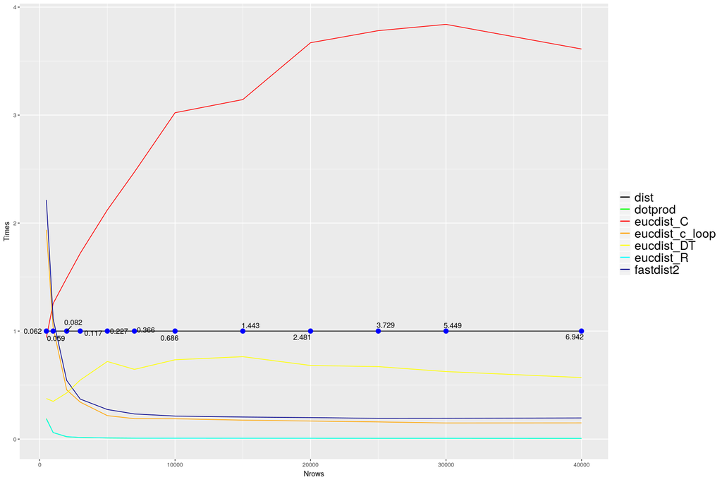

```python
# %%R
options(repr.plot.width=15, repr.plot.height = 10)
g4
```

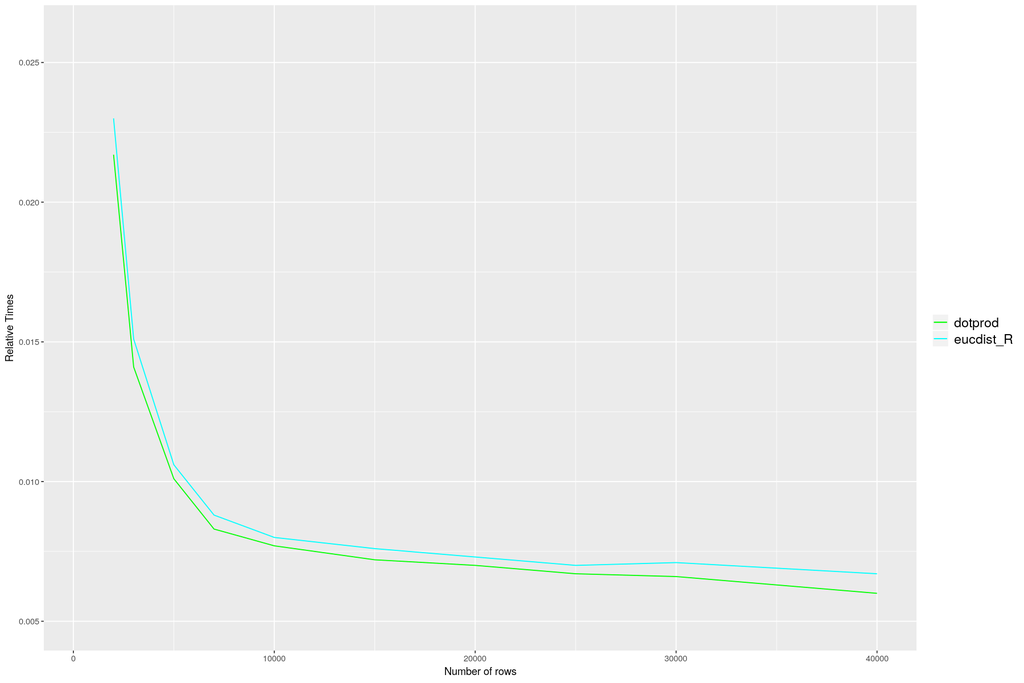

```python
g5 = g + geom_line(aes(y = dotprod, color = "dotprod")) +
    geom_line(aes(y = eucdist_R, color = "eucdist_R")) +  scale_color_manual(NULL,
    values=c(dotprod = "green", eucdist_R = "cyan")) +
    theme(legend.text = element_text(size=14)) + ylim(0.005, 0.026) + labs(y ="Relative Times", x = "Number of rows")
g5
```

```python
group_time$baseR_times <- time_base
cat("Relative Times")
group_time
```

```
Relative Times
```

A data.frame: 12 × 8

|  | dist <dbl> | dotprod <dbl> | eucdist_C <dbl> | eucdist_c_loop <dbl> | eucdist_DT <dbl> | eucdist_R <dbl> | fastdist2 <dbl> | baseR_times <dbl> |
| --- | --- | --- | --- | --- | --- | --- | --- | --- |
| 500 | 1 | 0.1890 | 0.9394 | 1.9375 | 0.3758 | 0.1851 | 2.2143 | 0.062 |
| 1000 | 1 | 0.0604 | 1.2553 | 1.0351 | 0.3491 | 0.0604 | 1.1132 | 0.059 |
| 2000 | 1 | 0.0217 | 1.4909 | 0.4556 | 0.4271 | 0.0230 | 0.5430 | 0.082 |
| 3000 | 1 | 0.0141 | 1.7206 | 0.3421 | 0.5467 | 0.0151 | 0.3703 | 0.117 |
| 5000 | 1 | 0.0101 | 2.1215 | 0.2172 | 0.7184 | 0.0106 | 0.2738 | 0.227 |
| 7000 | 1 | 0.0083 | 2.4730 | 0.1890 | 0.6455 | 0.0088 | 0.2327 | 0.366 |
| 10000 | 1 | 0.0077 | 3.0220 | 0.1883 | 0.7345 | 0.0080 | 0.2130 | 0.686 |
| 15000 | 1 | 0.0072 | 3.1438 | 0.1754 | 0.7631 | 0.0076 | 0.2043 | 1.443 |
| 20000 | 1 | 0.0070 | 3.6701 | 0.1670 | 0.6816 | 0.0073 | 0.1990 | 2.481 |
| 25000 | 1 | 0.0067 | 3.7819 | 0.1592 | 0.6709 | 0.0070 | 0.1918 | 3.729 |
| 30000 | 1 | 0.0066 | 3.8400 | 0.1489 | 0.6251 | 0.0071 | 0.1923 | 5.449 |
| 40000 | 1 | 0.0060 | 3.6119 | 0.1499 | 0.5696 | 0.0067 | 0.1956 | 6.942 |